# Chapter 7

Paloma

2019-12-27

# Exploratory Data Analysis

## 7.2. Questions

A **variable** is a quantity, quality, or *property that you can measure*.

A **value** is the *state of a variable when you measure it*. The value of a variable may change from measurement to measurement.

An **observation** is a set of measurements made under similar conditions (you usually make all of the measurements in an observation at the same time and on the same object). *An observation will contain several values, each associated with a different variable*. I’ll sometimes refer to an observation as a data point.

**Tabular data** is a *set of values, each associated with a variable and an observation*. Tabular data is tidy if each **value** is placed in its own **“cell”**, each **variable** in its own **column**, and each **observation** in its own **row**.

## Visualising distributions

### Categorical

- `geom_bar` works like a count, for proportions it needs the: `geom_bar(aes(y = ..prop.., group = 1))`. Neither `fill` or `color` work if it is the same variable as the categories when `y = ..prop..`.
- `geom_col` needs the categories in the x axis and the counts in Y, for a stacked, just add the second categorical variable in the count.

Fill also works differently in both

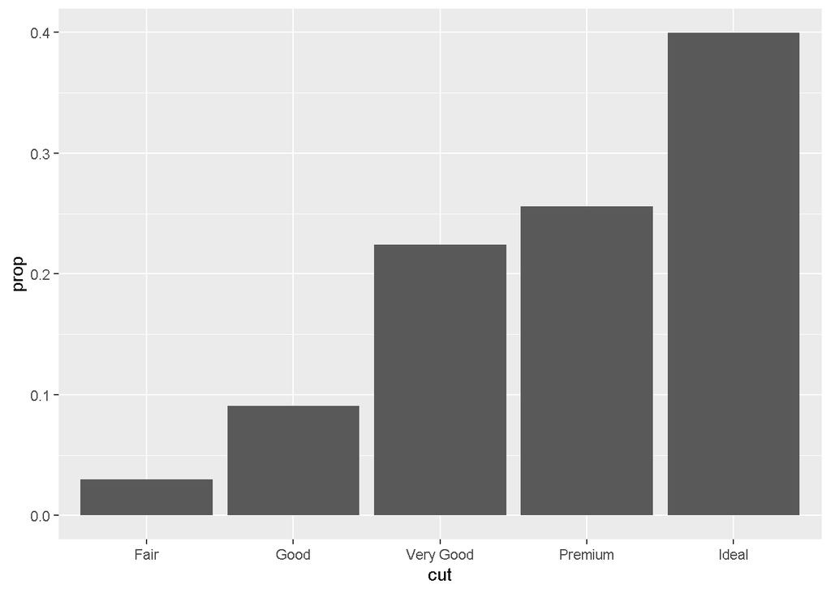

```r
diamonds %>%
  ggplot(aes(cut)) +
  geom_bar(aes(y = ..prop.., group = 1, fill = cut))
```

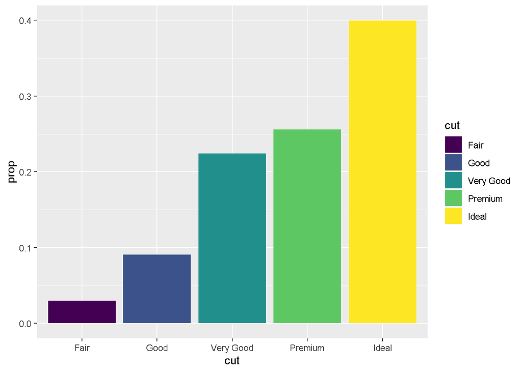

```r
diamonds %>%
  count(cut, name = "count") %>%
  mutate(prop = count/sum(count)) %>%
  ggplot(aes(cut, prop, fill = cut)) +
  geom_col()
```

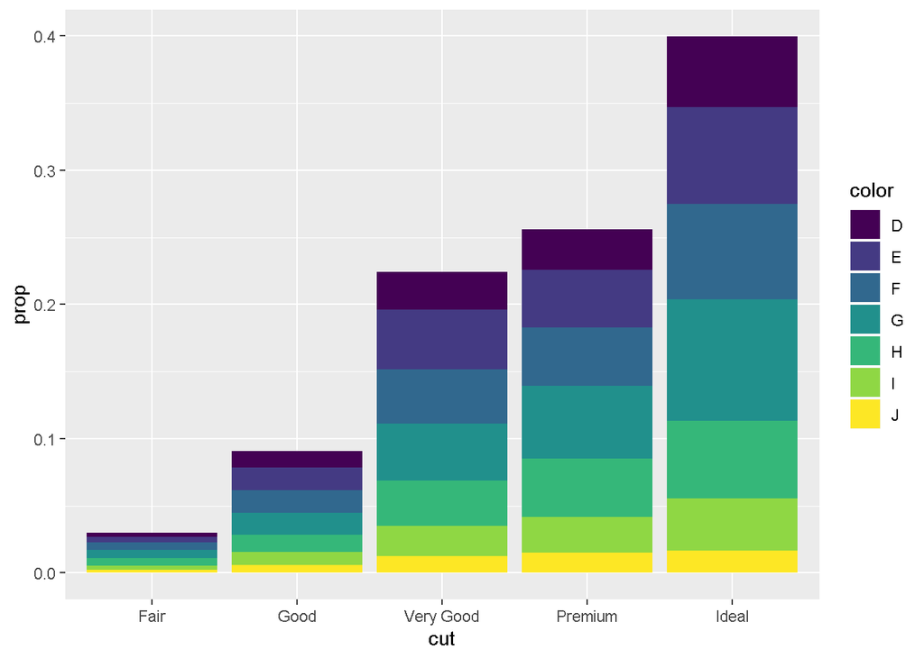

```r
diamonds %>%
  count(cut, color, name = "count") %>%
  mutate(prop = count/sum(count)) %>%
  ggplot(aes(cut, prop, fill = color)) +
  geom_col()
```

### Continuous

- `geom_histogram()`: remember the `binwidth` option
- `coord_cartesian`: helps reducing the x or y axis, this will help zoom in.
- `geom_freqpoly()`: if want to plot distributions by a **categorical** variable, but for this we also have `geom_boxplot()`.

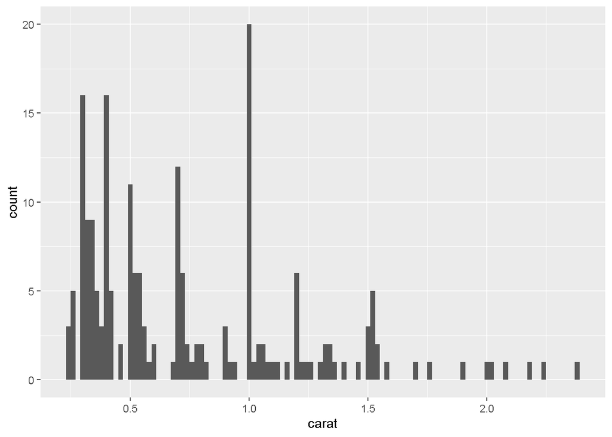

```r
diamonds %>%
  sample_n(200) %>%
  ggplot(aes(carat)) +
  geom_histogram(binwidth = 0.02)
```

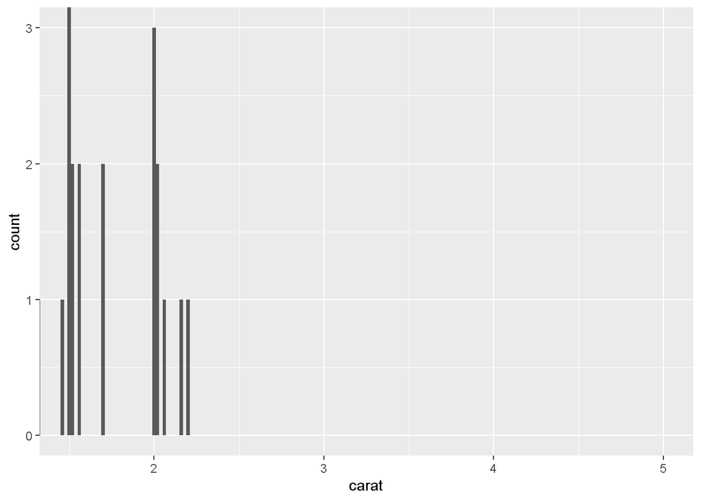

```r
diamonds %>%
  sample_n(200) %>%
  ggplot(aes(carat)) +
  geom_histogram(binwidth = 0.02) +
  coord_cartesian(xlim = c(1.5, 2,5), ylim = c(0,3))
```

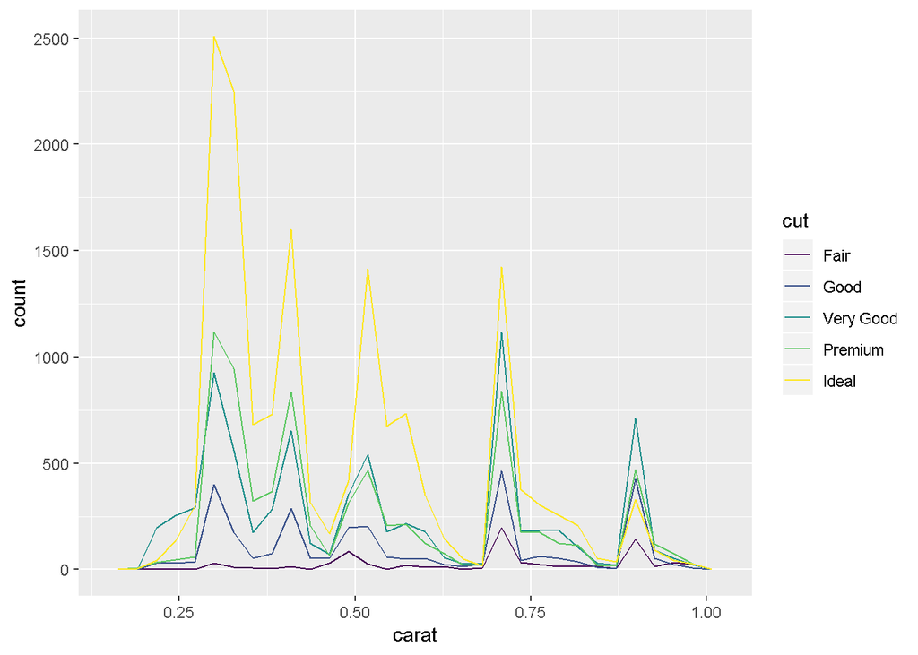

```r
diamonds %>%
  filter(carat < 1) %>%
  ggplot(aes(carat, color = cut)) +
  geom_freqpoly()
```

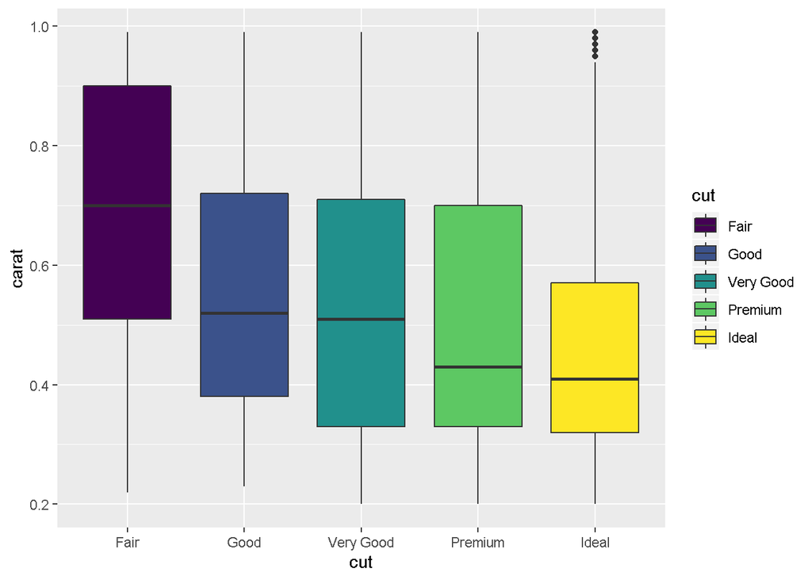

```r
diamonds %>%
  filter(carat < 1) %>%
  mutate(cut = fct_rev(fct_reorder(cut, carat))) %>%
  ggplot(aes(cut, carat, fill = cut)) +
  geom_boxplot()
```

### Two categorical

- `geom_count`
- `geom_tile`: first needs the counts, use fill for the ‘n’ to have the color tiles.

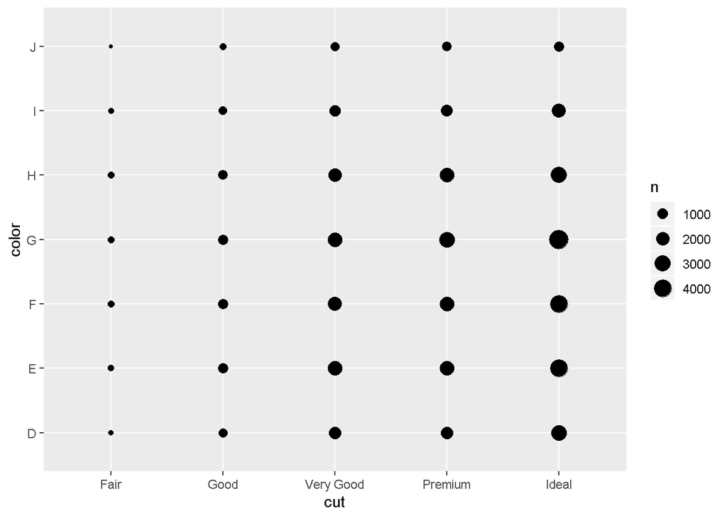

```r
ggplot(data = diamonds) +
  geom_count(mapping = aes(x = cut, y = color))
```

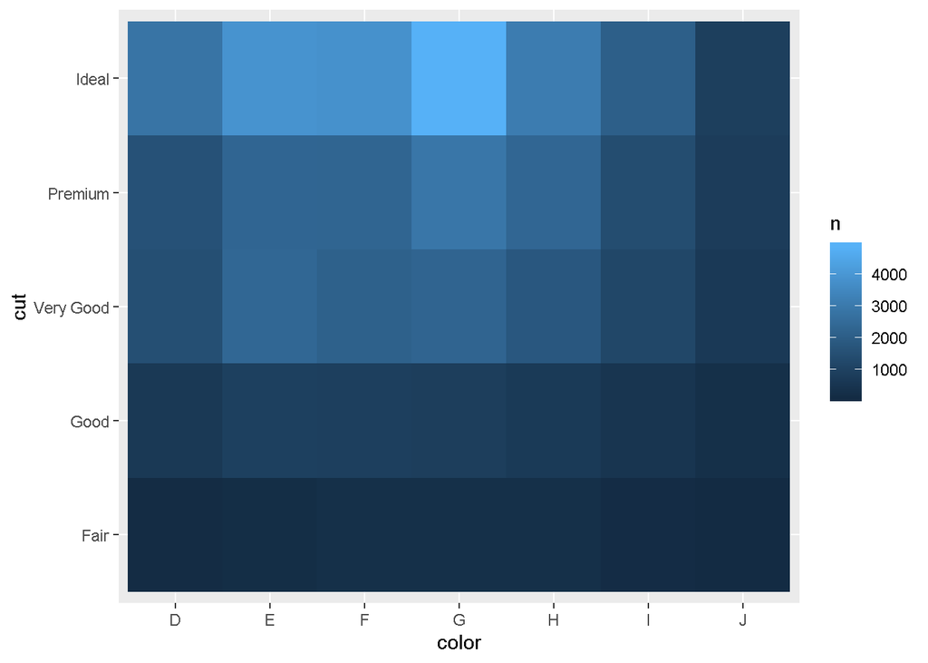

```r
diamonds %>%
  count(color, cut) %>%
  ggplot(aes(color, cut)) +
  geom_tile(aes(fill = n))
```

1. How could you rescale the count dataset above to more clearly show the distribution of cut within colour, or colour within cut?

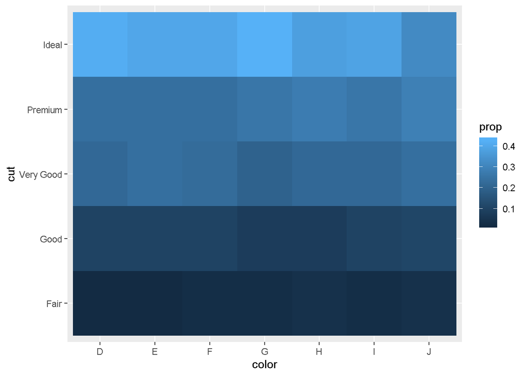

```r
diamonds %>%
  group_by(color) %>%
  count(cut) %>%
  mutate(total = sum(n),
         prop = round(n/total,2)) %>%
  ggplot(aes(color, cut)) +
  geom_tile(aes(fill = prop))
```

2. Use geom_tile() together with dplyr to explore how average flight delays vary by destination and month of year. What makes the plot difficult to read? How could you improve it?

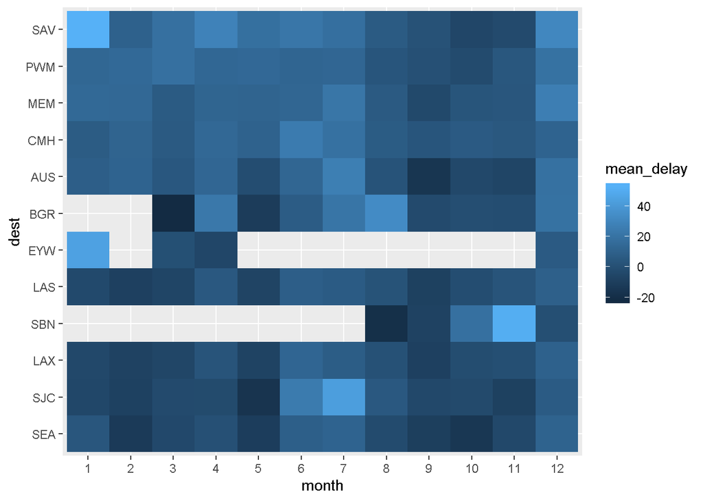

```r
destinations <- nycflights13::flights %>%
  count(dest) %>%
  sample_n(12) %>%
  pull(dest)

nycflights13::flights %>%
  filter(dest %in% destinations) %>%
  mutate(month = as_factor(month)) %>%
  group_by(dest, month) %>%
  summarise(mean_delay = round(mean(arr_delay, na.rm = TRUE),2)) %>%
  ungroup() %>%
  mutate(dest = fct_reorder(dest, mean_delay)) %>%
  ggplot(aes(month, dest)) +
  geom_tile(aes(fill = mean_delay))
```

### Two continuous

- `geom_point`: is usefull, but if the amount of points is large, `alpha` should be used.
- `geom_bin2d()`: makes tiles and fills for count of points
- `geom_hex()`: makes hexagons and fills for count of points
- `cut_width()`: we choose the width, so number of bins is calculated automatically.
- `cut_number()`: split a variable into groups, we specify number of bins and widths are calculated automatically.

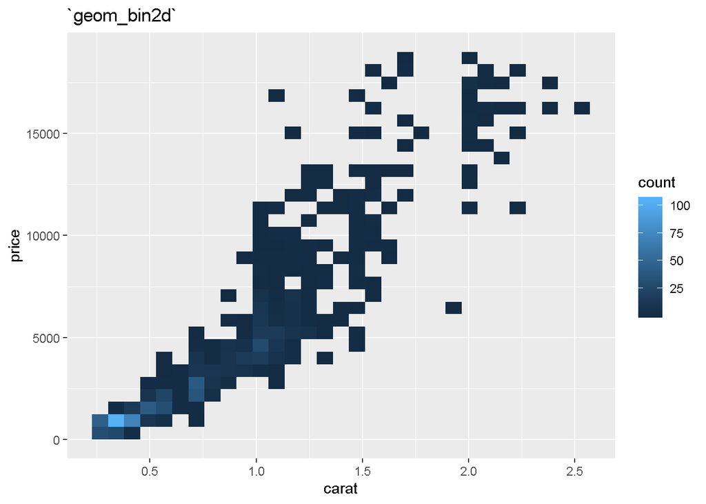

```r
library(hexbin)

diamonds %>%
  sample_n(1000) %>%
  ggplot(aes(carat, price)) +
  geom_bin2d() +
  labs(title = "`geom_bin2d`")
```

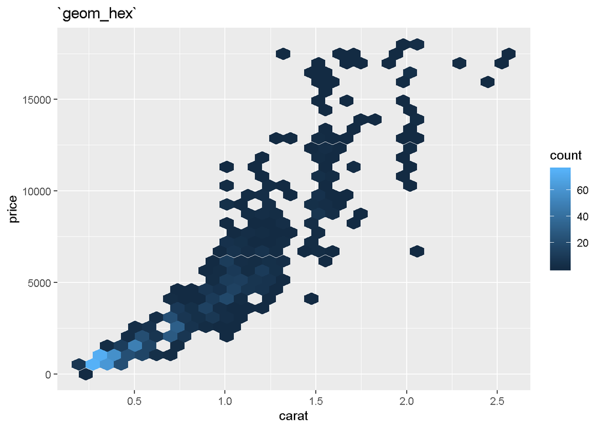

```r
diamonds %>%
  sample_n(1000) %>%
  ggplot(aes(carat, price)) +
  geom_hex() +
  labs(title = "`geom_hex`")
```

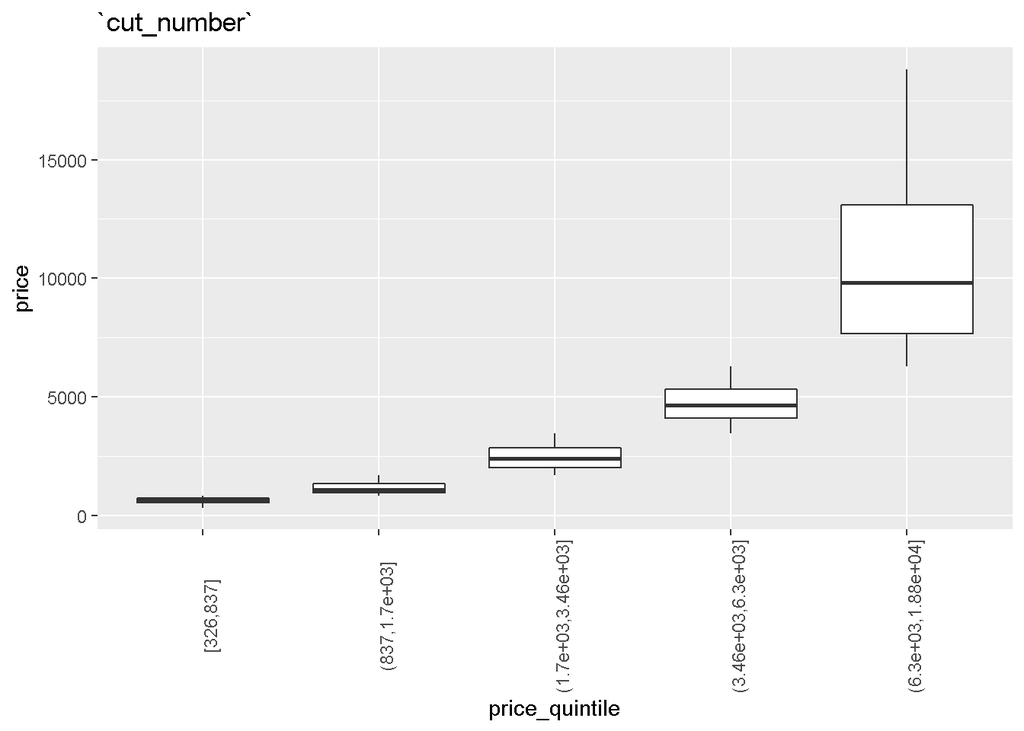

```r
diamonds %>%
  select(price) %>%
  mutate(price_quintile = cut_number(price, 5)) %>%
  ggplot(aes(x = price_quintile, y = price)) +
  geom_boxplot() +
  theme(axis.text.x = element_text(angle = 90)) +
  labs(title = "`cut_number`")
```

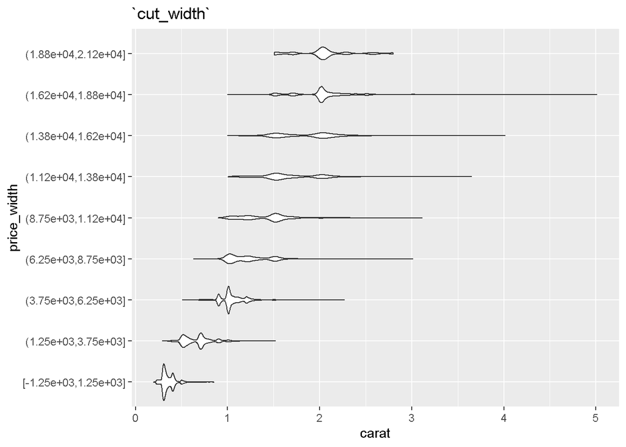

```r
diamonds %>%
  select(price, carat) %>%
  mutate(price_width = cut_width(price, 2500)) %>%
  ggplot(aes(price_width, carat)) +
  geom_violin() +
  coord_flip() +
  labs(title = "`cut_width`")
```

## Exercise

Combine two of the techniques you’ve learned to visualize the combined distribution of cut, carat, and price.

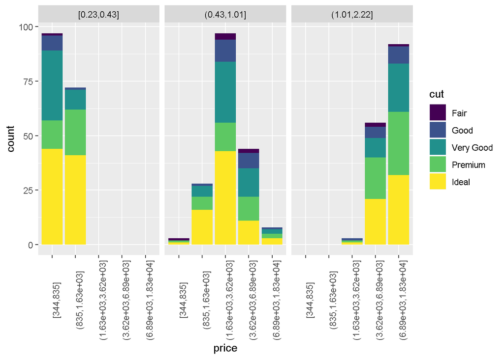

```r
diamonds %>%
  sample_n(500) %>%
  select(cut, carat, price) %>%
  mutate(price = cut_number(price, 5),
         carat = cut_number(carat, 3)) %>%
  ggplot(aes(price, fill = cut)) +
  geom_bar() +
  facet_wrap(.~ carat) +
  theme(axis.text.x = element_text(angle = 90))
```

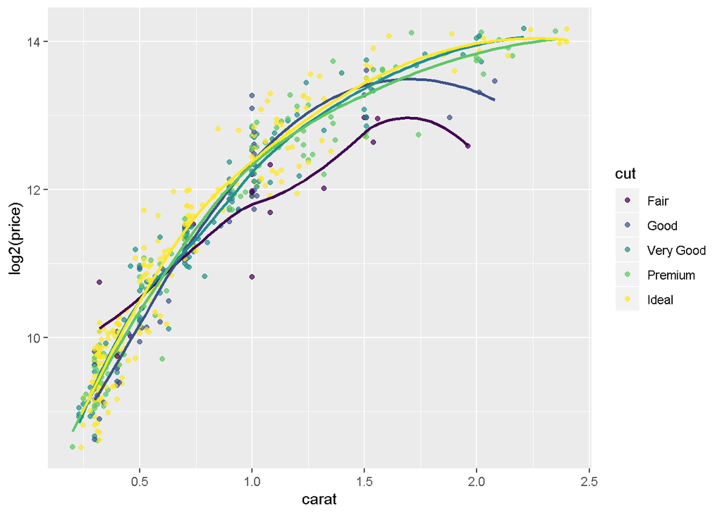

```r
diamonds %>%
  sample_n(500) %>%
  select(cut, carat, price) %>%
  ggplot(aes(carat, log2(price))) +
  geom_point(aes(color = cut), alpha = 0.7) +
  geom_smooth(aes(color = cut), se = FALSE, show.legend = FALSE)
```

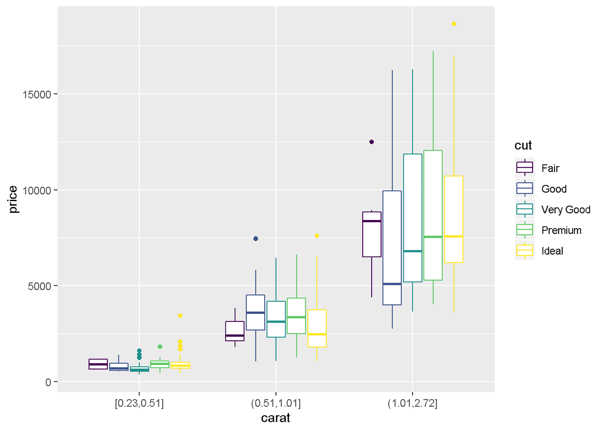

```r
diamonds %>%
  sample_n(500) %>%
  select(cut, carat, price) %>%
  mutate(carat = cut_number(carat, 3)) %>%
  ggplot(aes(carat, price, color = cut)) +
  geom_boxplot()
```

## Patterns and models

- Could this pattern be due to coincidence (i.e. random chance)?
- How can you describe the relationship implied by the pattern?
- How strong is the relationship implied by the pattern?
- What other variables might affect the relationship?
- Does the relationship change if you look at individual subgroups of the data?